# LAB-2 EDA

Aryan Vigyat 20BCE1452

2022-12-21

1. Creating the DataFrame with the given vectors

```r
x=c(2,3,4,5,6)
y=c(12,17,23,28,32)
df=data.frame(x,y)
print(df)
```

```
##   x  y
## 1 2 12
## 2 3 17
## 3 4 23
## 4 5 28
## 5 6 32
```

2. Find the best linear fit and graph of the model

```r
model1<-lm(y~x,data=df)
model1
```

```
##
## Call:
## lm(formula = y ~ x, data = df)
##
## Coefficients:
## (Intercept)            x
##         2.0          5.1
```

```r
summary(model1)
```

```
##
## Call:
## lm(formula = y ~ x, data = df)
##
## Residuals:
##    1    2    3    4    5
## -0.2 -0.3  0.6  0.5 -0.6
##
## Coefficients:
##             Estimate Std. Error t value Pr(>|t|)
## (Intercept)   2.0000     0.8124   2.462 0.090720 .
## x             5.1000     0.1915  26.634 0.000116 ***
## ---
## Signif. codes:  0 '***' 0.001 '**' 0.01 '*' 0.05 '.' 0.1 ' ' 1
##
## Residual standard error: 0.6055 on 3 degrees of freedom
## Multiple R-squared:  0.9958, Adjusted R-squared:  0.9944
## F-statistic: 709.4 on 1 and 3 DF,  p-value: 0.0001161
```

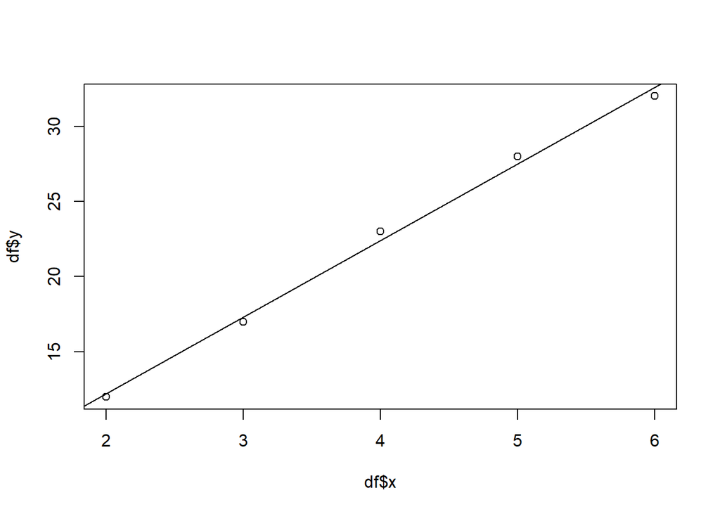

```r
plot(df$x,df$y)
abline(model1,col="black")
```

3. Determine the minimum RSS

```r
ypre=predict(model1,df)
ydiff=y-ypre
rss<-0
for(i in ydiff)
{
  rss=rss+i*i
}
rss
```

```
## [1] 1.1
```

4. Determine the TSS

```r
my=mean(df$y)
tssv=y-my
tss=sum(tssv*tssv)
print(tss)
```

```
## [1] 261.2
```

5. R<sup>2</sup> Statistics and Adjusted R<sup>2</sup> Statistics

```r
R_2=1-(rss/tss)
print("R-Square is ")
```

```
## [1] "R-Square is "
```

```r
print(R_2)
```

```
## [1] 0.9957887
```

```r
ADJR_2=1-((1-R_2)*(5-1)/(5-1-1))
print("Adjusted R-Square is ")
```

```
## [1] "Adjusted R-Square is "
```

```r
print(ADJR_2)
```

```
## [1] 0.9943849
```

6. Compute F-Statistic

```r
ssmv=ypre-my
ssm=sum(ssmv*ssmv)
n=nrow(df)
p=1
Fval=((ssm/p)/(rss/(n-p-1)))
print(Fval)
```

```
## [1] 709.3636
```

7. Hypothesis Definition and Comments  
   H0: The Coefficients of the Regression Equation are 0 i.e β1 β0 are zero  
   H1: All Coefficients of the Regression Equation are not simultaneously 0

```r
fcrit=qf(p=.05, df1=1, df2=3, lower.tail=FALSE)
print(fcrit)
```

```
## [1] 10.12796
```

```r
fstat=summary(model1)$fstatistic[1]
print(fstat)
```

```
##    value
## 709.3636
```

```r
df1=1
df2=3
pvalue=pf(fstat,df1,df2,lower.tail=F)
print(pvalue)
```

```
##        value
## 0.0001161362
```

Looking at the P-Value it is less than 0.05 so we reject the Null Hypothesis to conclude There is a relationship between the variables of the regression equation. Also Comparing the F-Critical Value to F-Stat Value We can see there is a very significant difference in them which shows model is a good fit for predicting the target variable.

2<sup>nd</sup> Question

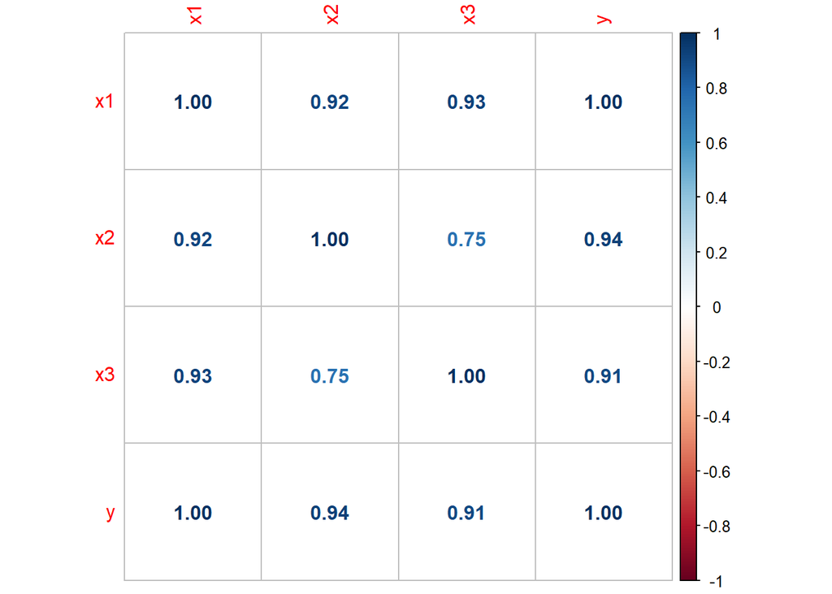

```r
library(corrplot)
df1=data.frame(x1=c(2,3,4,5,6),x2=c(14,15,26,27,28),x3=c(45,89,100,290,478),y=c(12,17,23,28,32))
cdf1=cor(df1)
df2=data.frame(x1=c(2,3,4,5,6),x2=c(14,15,26,27,28),x3=c(4,6,8,10,12),y=c(12,17,23,28,32))
corrplot(cdf1,method='number')
```

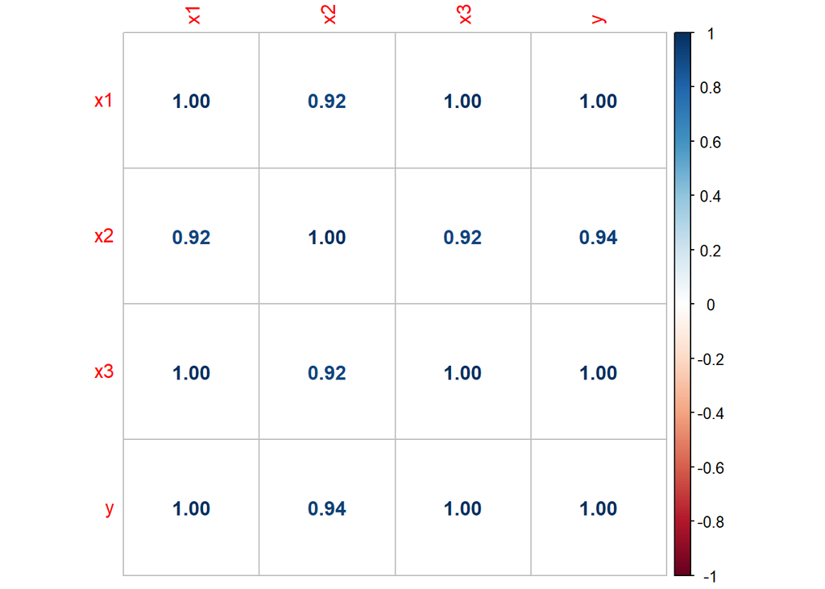

```r
cdf2=cor(df2)
corrplot(cdf2,method="number")
```

ii)Finding the Regression Equations

```r
model2=lm(y~x1+x2+x3,data=df1)
model3=lm(y~x1+x2+x3,data=df2)
summary(model2)
```

```
##
## Call:
## lm(formula = y ~ x1 + x2 + x3, data = df1)
##
## Residuals:
##         1         2         3         4         5
## -0.002315  0.002315 -0.166646  0.335606 -0.168960
##
## Coefficients:
##              Estimate Std. Error t value Pr(>|t|)
## (Intercept)  0.591677   0.891737   0.664    0.627
## x1           5.039228   0.861298   5.851    0.108
## x2           0.106111   0.109422   0.970    0.510
## x3          -0.003408   0.004482  -0.760    0.586
##
## Residual standard error: 0.411 on 1 degrees of freedom
## Multiple R-squared:  0.9994, Adjusted R-squared:  0.9974
## F-statistic:   515 on 3 and 1 DF,  p-value: 0.03238
```

```r
summary(model3)
```

```
##
## Call:
## lm(formula = y ~ x1 + x2 + x3, data = df2)
##
## Residuals:
##        1        2        3        4        5
## -0.20000  0.20000 -0.06667  0.33333 -0.26667
##
## Coefficients: (1 not defined because of singularities)
##             Estimate Std. Error t value Pr(>|t|)
## (Intercept)  1.00000    0.63246   1.581  0.25464
## x1           4.43333    0.29059  15.256  0.00427 **
## x2           0.16667    0.06667   2.500  0.12961
## x3                NA         NA      NA       NA
## ---
## Signif. codes:  0 '***' 0.001 '**' 0.01 '*' 0.05 '.' 0.1 ' ' 1
##
## Residual standard error: 0.3651 on 2 degrees of freedom
## Multiple R-squared:  0.999,  Adjusted R-squared:  0.998
## F-statistic: 978.5 on 2 and 2 DF,  p-value: 0.001021
```

### Conclusion

Looking at the Summary Statistic of the Model consisting the Second Dataset, We get to know that two variables are very highly correlated i.e correlation is 1 so one of the variables is not considered (as we know independent variables are always considered for regression) and The R-Square Value is 0.999 which shows that the model is a good fit to predict the response variable and for the first dataset we cam see the R-Square value is 0.99 which shows there is a good relationship between the dependent variables to predict the target variable which is also fortified by considering the p-Value i.e is 0.03<0.05

3<sup>rd</sup> Question  
1. Loading & Data Preprocessing

```r
library(readr)
library(dplyr)
library(superml)
library(e1071)
df <-read.csv("C:/Users/ayuar/Downloads/diamonds.csv")
head(df,5)
```

```
##   carat     cut color clarity depth table price    x    y    z
## 1  0.23   Ideal     E     SI2  61.5    55   326 3.95 3.98 2.43
## 2  0.21 Premium     E     SI1  59.8    61   326 3.89 3.84 2.31
## 3  0.23    Good     E     VS1  56.9    65   327 4.05 4.07 2.31
## 4  0.29 Premium     I     VS2  62.4    58   334 4.20 4.23 2.63
## 5  0.31    Good     J     SI2  63.3    58   335 4.34 4.35 2.75
```

```r
tail(df,5)
```

```
##       carat       cut color clarity depth table price    x    y    z
## 53936  0.72     Ideal     D     SI1  60.8    57  2757 5.75 5.76 3.50
## 53937  0.72      Good     D     SI1  63.1    55  2757 5.69 5.75 3.61
## 53938  0.70 Very Good     D     SI1  62.8    60  2757 5.66 5.68 3.56
## 53939  0.86   Premium     H     SI2  61.0    58  2757 6.15 6.12 3.74
## 53940  0.75     Ideal     D     SI2  62.2    55  2757 5.83 5.87 3.64
```

```r
str(df)
```

```
## 'data.frame':    53940 obs. of  10 variables:
##  $ carat  : num  0.23 0.21 0.23 0.29 0.31 0.24 0.24 0.26 0.22 0.23 ...
##  $ cut    : chr  "Ideal" "Premium" "Good" "Premium" ...
##  $ color  : chr  "E" "E" "E" "I" ...
##  $ clarity: chr  "SI2" "SI1" "VS1" "VS2" ...
##  $ depth  : num  61.5 59.8 56.9 62.4 63.3 62.8 62.3 61.9 65.1 59.4 ...
##  $ table  : num  55 61 65 58 58 57 57 55 61 61 ...
##  $ price  : int  326 326 327 334 335 336 336 337 337 338 ...
##  $ x      : num  3.95 3.89 4.05 4.2 4.34 3.94 3.95 4.07 3.87 4 ...
##  $ y      : num  3.98 3.84 4.07 4.23 4.35 3.96 3.98 4.11 3.78 4.05 ...
##  $ z      : num  2.43 2.31 2.31 2.63 2.75 2.48 2.47 2.53 2.49 2.39 ...
```

```r
summary(df)
```

```
##      carat            cut               color             clarity
##  Min.   :0.2000   Length:53940       Length:53940       Length:53940
##  1st Qu.:0.4000   Class :character   Class :character   Class :character
##  Median :0.7000   Mode  :character   Mode  :character   Mode  :character
##  Mean   :0.7979
##  3rd Qu.:1.0400
##  Max.   :5.0100
##      depth           table           price             x
##  Min.   :43.00   Min.   :43.00   Min.   :  326   Min.   : 0.000
##  1st Qu.:61.00   1st Qu.:56.00   1st Qu.:  950   1st Qu.: 4.710
##  Median :61.80   Median :57.00   Median : 2401   Median : 5.700
##  Mean   :61.75   Mean   :57.46   Mean   : 3933   Mean   : 5.731
##  3rd Qu.:62.50   3rd Qu.:59.00   3rd Qu.: 5324   3rd Qu.: 6.540
##  Max.   :79.00   Max.   :95.00   Max.   :18823   Max.   :10.740
##        y                z
##  Min.   : 0.000   Min.   : 0.000
##  1st Qu.: 4.720   1st Qu.: 2.910
##  Median : 5.710   Median : 3.530
##  Mean   : 5.735   Mean   : 3.539
##  3rd Qu.: 6.540   3rd Qu.: 4.040
##  Max.   :58.900   Max.   :31.800
```

```r
sum(is.na(df$carat))
```

```
## [1] 0
```

```r
sum(is.na(df$color))
```

```
## [1] 0
```

```r
sum(is.na(df$cut))
```

```
## [1] 0
```

```r
sum(is.na(df$clarity))
```

```
## [1] 0
```

```r
sum(is.na(df$depth))
```

```
## [1] 0
```

```r
sum(is.na(df$table))
```

```
## [1] 0
```

```r
sum(is.na(df$x))
```

```
## [1] 0
```

```r
sum(is.na(df$y))
```

```
## [1] 0
```

```r
sum(is.na(df$y))
```

```
## [1] 0
```

```r
df$...1<-NULL
df<-filter(df,x>0,y>0,z>0)
print("As NA Values are 0 the dataset is perfectly fine for analysis")
```

```
## [1] "As NA Values are 0 the dataset is perfectly fine for analysis"
```

2. Encoding the Categorical Values

```r
label <- LabelEncoder$new()
df$cut <- label$fit_transform(df$cut)
df$color <- label$fit_transform(df$color)
df$clarity <- label$fit_transform(df$clarity)
newdf<-df
```

3. Correlation Check

```r
cor.test(df$price,df$carat)
```

```
##
##  Pearson's product-moment correlation
##
## data:  df$price and df$carat
## t = 551.31, df = 53918, p-value < 2.2e-16
## alternative hypothesis: true correlation is not equal to 0
## 95 percent confidence interval:
##  0.9203104 0.9228540
## sample estimates:
##       cor
## 0.9215921
```

```r
cor.test(df$price,df$cut)
```

```
##
##  Pearson's product-moment correlation
##
## data:  df$price and df$cut
## t = 11.51, df = 53918, p-value < 2.2e-16
## alternative hypothesis: true correlation is not equal to 0
## 95 percent confidence interval:
##  0.04108325 0.05792314
## sample estimates:
##        cor
## 0.04950671
```

```r
cor.test(df$price,df$clarity)
```

```
##
##  Pearson's product-moment correlation
##
## data:  df$price and df$clarity
## t = -32.891, df = 53918, p-value < 2.2e-16
## alternative hypothesis: true correlation is not equal to 0
## 95 percent confidence interval:
##  -0.1485141 -0.1319648
## sample estimates:
##        cor
## -0.1402492
```

```r
cor.test(df$price,df$x)
```

```
##
##  Pearson's product-moment correlation
##
## data:  df$price and df$x
## t = 446.58, df = 53918, p-value < 2.2e-16
## alternative hypothesis: true correlation is not equal to 0
## 95 percent confidence interval:
##  0.8854215 0.8890144
## sample estimates:
##       cor
## 0.8872314
```

```r
cor.test(df$price,df$y)
```

```
##
##  Pearson's product-moment correlation
##
## data:  df$price and df$y
## t = 405.64, df = 53918, p-value < 2.2e-16
## alternative hypothesis: true correlation is not equal to 0
## 95 percent confidence interval:
##  0.8657656 0.8699323
## sample estimates:
##       cor
## 0.8678642
```

```r
cor.test(df$price,df$z)
```

```
##
##  Pearson's product-moment correlation
##
## data:  df$price and df$z
## t = 406.28, df = 53918, p-value < 2.2e-16
## alternative hypothesis: true correlation is not equal to 0
## 95 percent confidence interval:
##  0.8661128 0.8702695
## sample estimates:
##       cor
## 0.8682064
```

```r
cor.test(df$price,df$table)
```

```
##
##  Pearson's product-moment correlation
##
## data:  df$price and df$table
## t = 29.789, df = 53918, p-value < 2.2e-16
## alternative hypothesis: true correlation is not equal to 0
## 95 percent confidence interval:
##  0.1189324 0.1355404
## sample estimates:
##       cor
## 0.1272453
```

```r
cor.test(df$price,df$depth)
```

```
##
##  Pearson's product-moment correlation
##
## data:  df$price and df$depth
## t = -2.4914, df = 53918, p-value = 0.01273
## alternative hypothesis: true correlation is not equal to 0
## 95 percent confidence interval:
##  -0.019167817 -0.002288498
## sample estimates:
##         cor
## -0.01072892
```

```r
#Insights
#Looking at the Results We Can Conclude Price has a Strong Correlation with Carat,x,y,z and less correlation with Clarity,Depth and Table
```

4. Creating the Model

```r
model1=lm(price~color+carat+clarity+cut,data=newdf)
summary(model1)
```

```
##
## Call:
## lm(formula = price ~ color + carat + clarity + cut, data = newdf)
##
## Residuals:
##      Min       1Q   Median       3Q      Max
## -20665.2   -671.6    -82.7    519.5  11337.4
##
## Coefficients:
##              Estimate Std. Error t value Pr(>|t|)
## (Intercept) -3256.765     20.478 -159.03   <2e-16 ***
## color          80.095      3.045   26.30   <2e-16 ***
## carat        8116.200     13.771  589.38   <2e-16 ***
## clarity       280.702      3.690   76.07   <2e-16 ***
## cut          -141.655      4.974  -28.48   <2e-16 ***
## ---
## Signif. codes:  0 '***' 0.001 '**' 0.01 '*' 0.05 '.' 0.1 ' ' 1
##
## Residual standard error: 1446 on 53915 degrees of freedom
## Multiple R-squared:  0.8684, Adjusted R-squared:  0.8684
## F-statistic: 8.898e+04 on 4 and 53915 DF,  p-value: < 2.2e-16
```

```r
fcrit=qf(p=.05, df1=4, df2=53915, lower.tail=FALSE)
print(fcrit)
```

```
## [1] 2.372097
```

```r
print(summary(model1)$fstatistic[1] )
```

```
##   value
## 88981.8
```